# MSDS 6372 Project 2: Modeling Bank Customer Term Deposit Subscription Behavior to Improve Marketing Efforts

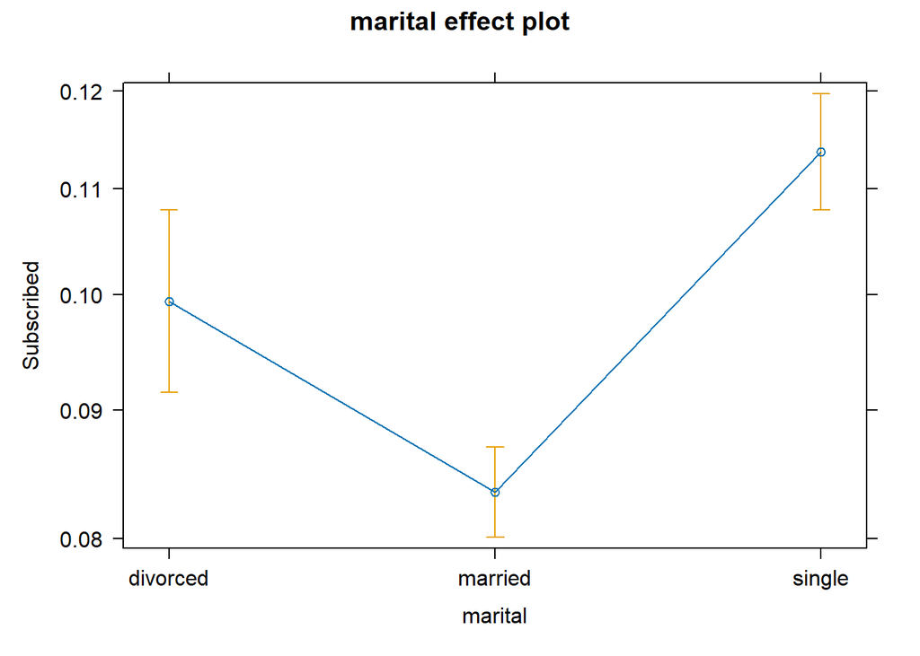

```r
plot(Effect("marital", full_model_2))
```

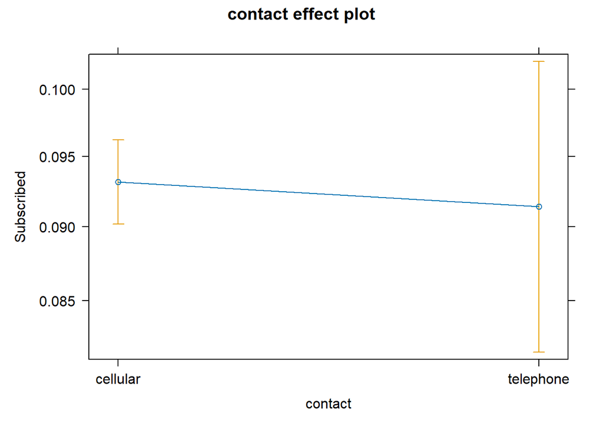

```r
plot(Effect("contact", full_model_2))
```

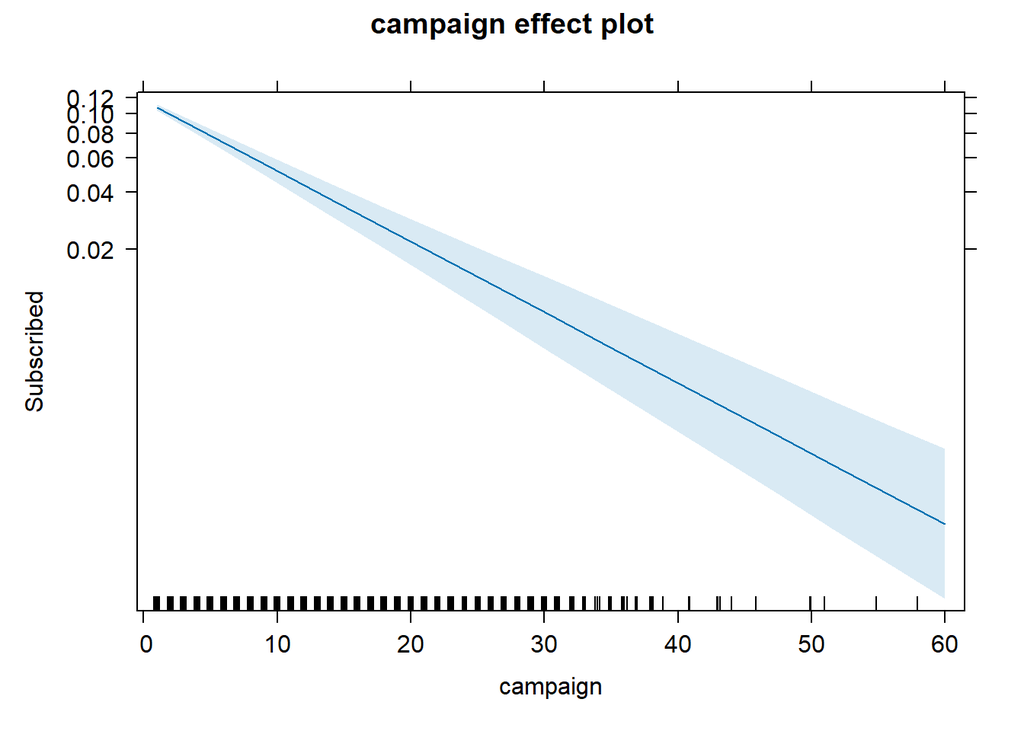

```r
plot(Effect("campaign", full_model_2)) # People do NOT like to be harassed!!
```

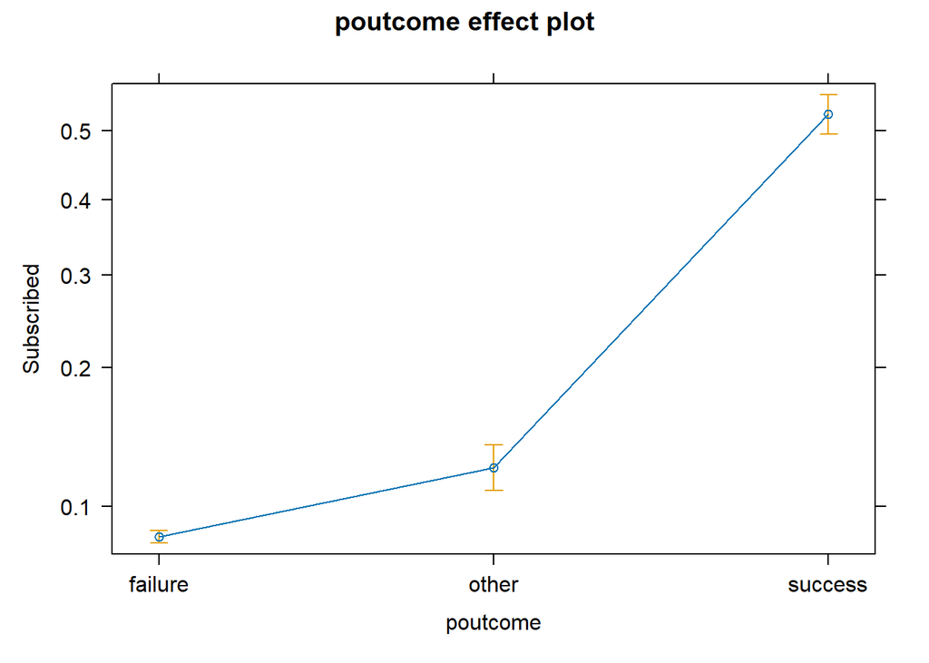

```r
plot(Effect("poutcome", full_model_2))
```

# Objective 2: Nonadditive Logisitic Regression

Build a model where prediction performance is prioritized. SET AN OVERALL OBJECTIVE: Predicting if a customer will subscribe to a term deposit Determine an appropriate threshold for each model that MEETS THE OVERALL OBJECTIVE YOU HAVE SET out when discussing the accuracy metrics in the previous bullet point. (Here we are asked to choose which is worse: false positives or false negatives. And we should address the cost of false positives vs the cost false negatives!) HAVE A TRAIN/VALIDATION SPLIT! User simple logistic regression model as a baseline: perform additional competing models to improve on prediction performance metrics • Build 4-5 additional classification models to compare to your model in OBJECTIVE1. ONE MODEL should be an attempt at a COMPLEX LOGISTIC REGRESSION MODEL INCLUDING INTERACTION TERMS OR POLYNOMIAL TERMS. • DO FEATURE SELECTION for the logistic model here. If feature selection suggests that you do not include any interaction terms or polynomials, state this and include them anyways as an experiment. ONE MODEL should be an LDA and QDA model. AT LEAST ONE MODEL should be a nonparametric model such as knn, random forest, classification tree. • COMPLEX LOGISTIC REGRESSION MODEL quick discussion on the reasoning for the complexity you added to the model Perhaps another slide on a deeper dive of EDA or discussion on logistical points based on your own knowledge of the variables. Similarly for LDA and QDA, EDA from earlier (or now) should include some commentary on whether or not the assumptions made these tools appear to be violated or not. Comment on the assumptions, but it is optional to try to fix them. This could perhaps be why these methods don’t perform well compared to others. • Define what Sensitivity, Specificity, PPV, and NPV mean in context to your project. The group should discuss if they think one or two metrics should be prioritized over the others. THIS STEP IS CRITICAL!!! • For each model, 6 metrics should be computed and reported using the validation set. The Sensitivity, Specificity, Prevalence, PPV, NPV, and AUROC. Reporting the K-FOLD LOGLOSS METRIC would also be helpful to include if you performed k-fold CV during the training step. Make sure to communicate what threshold you are using that derives many of the metrics. • Provide model ROC in either a panel graph or a single graph with models labeled in a legend. With a lot of models it may be helpful to organize them in two graphs to help communicate a point. • Based on the model comparisons, RECOMMEND A FINAL MODEL for PREDICTIONS. Provide any insights on why some models performed better than others OR making note if all models are about the same OR perhaps it should be noted that all the models are bad practically speaking. LOGISTICAL CONSIDERATIONS. • PCA might be helpful in various ways throughout your analysis • Other UNSUPERVISED tools such as HEATMAPS and CLUSTER ANALYSIS from Unit 13 and 14. • If there is a clear opportunity to use PCA in the project, Turner expects us to try it. • Clustering is optional.

## Implications of Strong Class Imbalance:

Discuss the No-Information rate because most responses are no, blindly choosing no will be right most of the time. Accuracy becomes misleading A model that predicts “no” for everyone would still be about 90% accurate but it would be useless, because it would never identify the “yes” cases. Biased Training Many models (like logistic regression, random forest) can bias toward the majority class if not handled carefully. Low Sensitivity For The “Yes” Class We may get low sensitivity/recall for the “yes” class (failing to identify real subscribers). In this study: missing “yes” = missed marketing opportunities. Ways To Handle A Strong Class Imbalance: Use precision, recall, F1-score, AUC, not just accuracy.

```r
# Identifying The Optimal Threshold For Our Imbalanced Data Using Youden's Index
library(pROC)
# names(validation)
validation$prob <- predict(obj1_model1, newdata = validation, type = "response")
# list the negative class first, positive class second!!
roc_obj <- roc(validation$Subscribed, validation$prob, levels = c("no", "yes"))
youden    <- coords(roc_obj, x = "best", best.method = "youden", transpose = FALSE)
youden
```

```
##   threshold specificity sensitivity
## 1 0.1258639   0.8299098   0.5373699
```

```r
myThreshold  <- youden$threshold
myThreshold
```

```
## [1] 0.1258639
```

```r
validation$predicted_class <- ifelse(validation$prob >= myThreshold, "yes", "no")
validation$predicted_class <- factor(validation$predicted_class, levels = c("no", "yes"))
confusionMatrix(data = validation$predicted_class, reference = validation$Subscribed, positive = "yes")
```

```
## Confusion Matrix and Statistics
##
##           Reference
## Prediction   no  yes
##        no  6626  489
##        yes 1358  568
##
##                Accuracy : 0.7957
##                  95% CI : (0.7872, 0.804)
##     No Information Rate : 0.8831
##     P-Value [Acc > NIR] : 1
##
##                   Kappa : 0.2707
##
##  Mcnemar's Test P-Value : <2e-16
##
##             Sensitivity : 0.53737
##             Specificity : 0.82991
##          Pos Pred Value : 0.29491
##          Neg Pred Value : 0.93127
##              Prevalence : 0.11691
##          Detection Rate : 0.06282
##    Detection Prevalence : 0.21303
##       Balanced Accuracy : 0.68364
##
##        'Positive' Class : yes
##
```

## Identifying The Optimal Threshold For Our Imbalanced Data Using Youden’s Index

Must come AFTER running a model, in fact, after EACH model for which we wish to identify the best threshold Super imbalanced data set (way more NO than YES) youden criterion=max(sensitivities+specificities) Youden’s Index (J)=Bookmaker Informedness (BM)=Sensitivity + Specificity - 1 Youden’s Index = a single value that summarizes the performance of a diagnostic test. Helps determine the optimal cutoff point for a diagnostic test

## knn

```r
# library(caret)
# fitControl<-trainControl(method="repeatedcv",number=5,repeats=1,classProbs=TRUE, summaryFunction=mnLogLoss)
# set.seed(1234)
# knn.fit<-train(Subscribed~age+balance,data=bank_full,method="knn",trControl=fitControl,metric="logLoss")
# # Creating a validation set across the whole graph
# validation KNN <- expand.grid(age=seq(-10, 10, by=0.25), balance=seq(-15, 15, by=0.5))
# # Computing predicted probabilities on the training data
# predictions <- predict(knn.fit, validationKNN, type="prob")[,"Yes"]
# threshold=0.5
# class_pred=as.factor(ifelse(predictions>myThreshold, "1", "0"))
# color_array <- c("black", "red")[as.numeric(class_pred)]
#  par(mfrow=c(1,2))
#   plot(bank_full$age,bank_full$balance,col=bank_full$Subscribed,asp=1,pch=16,cex=.7,xlab="age",ylab="balance")
#   plot(validationKNN,col=color_array,pch=20,cex=0.15)
#  par(mfrow=c(1,2))
```

## See what the decision boundary is for an LDA model and a QDA model:

```r
library(MASS)
```

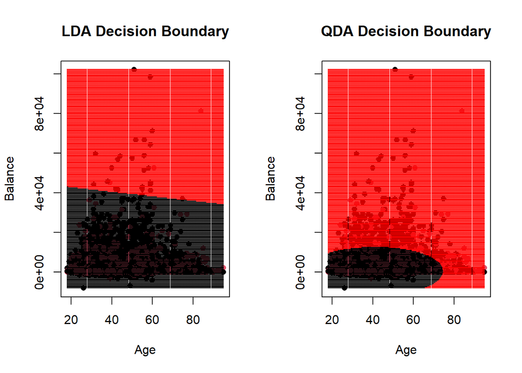

```r
library(ggplot2)

## Fit LDA and QDA models using age and balance
 lda.fit <- lda(Subscribed~age+balance,data=bank_full)
 qda.fit <- qda(Subscribed~age+balance,data=bank_full)

 # Create grid of values for prediction
 age.range <- seq(min(bank_full$age),max(bank_full$age),length.out=200)
 balance.range <- seq(min(bank_full$balance),max(bank_full$balance),length.out=200)
 grid <- expand.grid(age=age.range,balance=balance.range)

 # Predict class for each point in the grid
 lda.pred <- predict(lda.fit,grid)$class
 qda.pred <- predict(qda.fit,grid)$class

 # Plot decision boundaries
 par(mfrow=c(1,2))
    # LDA
        plot(bank_full$age,bank_full$balance,col=bank_full$Subscribed,pch=16,xlab="Age",ylab="Balance",main="LDA Decision Boundary")
        points(grid$age,grid$balance,col=c("black","red")[as.numeric(lda.pred)],pch=20,cex=0.1)
    # QDA
        plot(bank_full$age,bank_full$balance,col=bank_full$Subscribed,pch=16,xlab="Age",ylab="Balance",main="QDA Decision Boundary")
        points(grid$age,grid$balance,col=c("black","red")[as.numeric(qda.pred)],pch=20,cex=0.1)
```

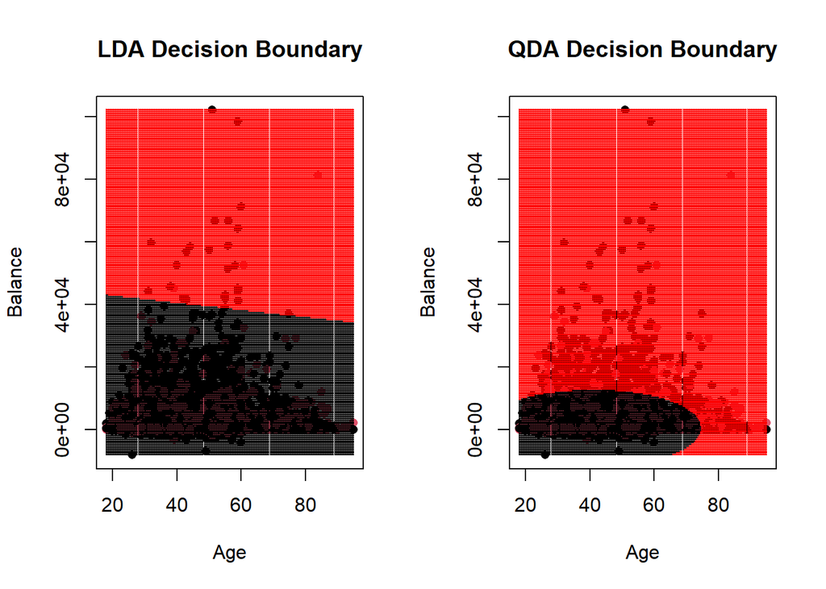

```r
 par(mfrow=c(1,1))


## Fit LDA and QDA using duration and pdays
 lda.fit <- lda(Subscribed~duration+pdays,data=bank_full)
 qda.fit <- qda(Subscribed~duration+pdays,data=bank_full)

 # Create prediction grid
 age.range <- seq(min(bank_full$duration), max(bank_full$duration), length.out=200)
 balance.range <- seq(min(bank_full$pdays), max(bank_full$pdays), length.out=200)
 grid <- expand.grid(duration=age.range, pdays=balance.range)

 # Predict class for each point in grid
 lda.pred <- predict(lda.fit, grid)$class
 qda.pred <- predict(qda.fit, grid)$class

 # Plot decision boundaries
 par(mfrow=c(1, 2))


## Fit LDA and QDA models using age and balance
 lda.fit <- lda(Subscribed~age+balance,data=bank_full)
 qda.fit <- qda(Subscribed~age+balance,data=bank_full)

 # Create grid of values for prediction
 age.range <- seq(min(bank_full$age),max(bank_full$age),length.out=200)
 balance.range <- seq(min(bank_full$balance),max(bank_full$balance),length.out=200)
 grid <- expand.grid(age=age.range,balance=balance.range)

 # Predict class for each point in the grid
 lda.pred <- predict(lda.fit,grid)$class
 qda.pred <- predict(qda.fit,grid)$class


 # Plot decision boundaries
 par(mfrow=c(1,2))
    # LDA
        plot(bank_full$age,bank_full$balance,col=bank_full$Subscribed,pch=16,xlab="Age",ylab="Balance",main="LDA Decision Boundary")
        points(grid$age,grid$balance,col=c("black","red")[as.numeric(lda.pred)],pch=20,cex=0.1)
    # QDA
        plot(bank_full$age,bank_full$balance,col=bank_full$Subscribed,pch=16,xlab="Age",ylab="Balance",main="QDA Decision Boundary")
        points(grid$age,grid$balance,col=c("black","red")[as.numeric(qda.pred)],pch=20,cex=0.1)
```

```r
 par(mfrow=c(1,1))
lda.fit$scaling
```

```
##                 LD1
## age     0.033675209
## balance 0.000296006
```

```r
qda.fit$scaling
```

```
## , , no
##
##                   1             2
## age     -0.09830269 -0.0090265662
## balance  0.00000000  0.0003376399
##
## , , yes
##
##                   1             2
## age     -0.07408625 -0.0091238032
## balance  0.00000000  0.0002877819
```